# Lululemon Example Project - NHL Data

Russell Morton

The following R notebook contains an example analysis project using National Hockey League player and team data from 2007-2019. Whilst there are a number of columns present in the data sets, this analysis is concerned with investigating two and modelling two scenarios:

- Scenario 1: Does time on the ice affect the number of expected goals among all players?
- Scenario 2: Does position proivide an indication of the number of goals?

The project is hosted on GitHub at https://github.com/russellmorton/nhldataanalysis.

The data is available on GitHub at [NHL Data](https://github.com/jamesmartherus/nhldata).

The primary packages for analysis used in this sample project are from the [Tidyverse](https://www.tidyverse.org/) group of packages:

```r
library(tidyverse)
```

The data is sourced from GitHub using:

```r
devtools::install_github("jamesmartherus/nhldata")
library(nhldata)
```

For ease of use the variables are added to the Global Environment:

```r
skaters = nhldata::skaters
teams = nhldata::teams
head(skaters)
```

| player | season | team | team2 | team3 | position | position2 | position3 | gp | toi | g | a | p | p1 | p_60 | p1_60 | gs | gs_60 | cf | ca | c_plumin | cf_pct | rel_cf_pct | gf | ga | g_plumin | gf_pct | rel_gf_pct | xgf | xga | … |
| --- | --- | --- | --- | --- | --- | --- | --- | --- | --- | --- | --- | --- | --- | --- | --- | --- | --- | --- | --- | --- | --- | --- | --- | --- | --- | --- | --- | --- | --- | --- |
| SEBASTIAN AHO | 2017-2018 | NYI | NA | NA | D | D | R | 22 | 324.64 | 0 | 3 | 3 | 1 | 0.55 | 0.18 | 1.99 | 0.37 | 289 | 325 | -36 | 47.07 | 2.26 | 15 | 19 | -4 | 44.12 | -0.48 | 10.49 | 15.73 | … |
| AARON DOWNEY | 2007-2008 | DET | NA | NA | R | NA | NA | 56 | 253.35 | 0 | 2 | 2 | 2 | 0.47 | 0.47 | 0.92 | 0.22 | 193 | 183 | 10 | 51.33 | -7.30 | 6 | 6 | 0 | 50.00 | -12.50 | 7.16 | 7.76 | … |
| AARON EKBLAD | 2014-2015 | FLA | NA | NA | D | NA | NA | 81 | 1400.56 | 6 | 16 | 22 | 14 | 0.94 | 0.60 | 38.10 | 1.63 | 1299 | 1112 | 187 | 53.88 | 3.83 | 59 | 43 | 16 | 57.84 | 11.78 | 50.88 | 42.32 | … |
| AARON EKBLAD | 2015-2016 | FLA | NA | NA | D | NA | NA | 78 | 1319.22 | 9 | 13 | 22 | 15 | 1.00 | 0.68 | 28.15 | 1.28 | 1059 | 1034 | 25 | 50.60 | 2.92 | 56 | 43 | 13 | 56.57 | -3.07 | 42.44 | 44.38 | … |
| AARON EKBLAD | 2016-2017 | FLA | NA | NA | D | NA | NA | 68 | 1132.67 | 4 | 7 | 11 | 7 | 0.58 | 0.37 | 21.36 | 1.13 | 1084 | 1003 | 81 | 51.94 | 1.97 | 30 | 47 | -17 | 38.96 | -7.58 | 38.23 | 42.23 | … |
| AARON EKBLAD | 2017-2018 | FLA | NA | NA | D | NA | NA | 82 | 1440.06 | 9 | 11 | 20 | 11 | 0.83 | 0.46 | 19.78 | 0.82 | 1392 | 1520 | -128 | 47.80 | -2.16 | 69 | 67 | 2 | 50.74 | 1.50 | 57.36 | 65.83 | … |

```r
head(teams)
```

| team | season | gp | toi | cf | ca | c_plumin | cf_pct | cf_60 | ca_60 | gf | ga | g_plumin | gf_pct | gf_60 | ga_60 | xgf | xga | xg_plumin | xgf_pct | xgf_60 | xga_60 | pent | pend | p_plumin | sh_pct | sv_pct | pdo |
| --- | --- | --- | --- | --- | --- | --- | --- | --- | --- | --- | --- | --- | --- | --- | --- | --- | --- | --- | --- | --- | --- | --- | --- | --- | --- | --- | --- |
| ANA | 2007-2008 | 81 | 3396.38 | 2596 | 2523 | 73 | 50.71 | 45.86 | 44.57 | 107 | 95 | 12 | 52.97 | 1.89 | 1.68 | 108.93 | 114.61 | -5.68 | 48.73 | 1.92 | 2.02 | 406 | 372 | -34 | 7.30 | 93.62 | 100.93 |
| ANA | 2008-2009 | 82 | 3645.19 | 3060 | 2945 | 115 | 50.96 | 50.37 | 48.47 | 145 | 130 | 15 | 52.73 | 2.39 | 2.14 | 134.91 | 129.11 | 5.80 | 51.10 | 2.22 | 2.13 | 407 | 337 | -70 | 8.40 | 92.42 | 100.82 |
| ANA | 2009-2010 | 82 | 3746.91 | 3141 | 3493 | -352 | 47.35 | 50.30 | 55.93 | 146 | 144 | 2 | 50.34 | 2.34 | 2.31 | 132.19 | 156.27 | -24.08 | 45.83 | 2.12 | 2.50 | 378 | 351 | -27 | 8.23 | 92.75 | 100.98 |
| ANA | 2010-2011 | 82 | 3852.90 | 3024 | 3794 | -770 | 44.35 | 47.09 | 59.08 | 134 | 154 | -20 | 46.53 | 2.09 | 2.40 | 123.01 | 156.05 | -33.04 | 44.08 | 1.92 | 2.43 | 336 | 309 | -27 | 7.87 | 92.31 | 100.18 |
| ANA | 2011-2012 | 82 | 3890.68 | 3326 | 3526 | -200 | 48.54 | 51.29 | 54.38 | 138 | 154 | -16 | 47.26 | 2.13 | 2.37 | 133.14 | 149.34 | -16.20 | 47.13 | 2.05 | 2.30 | 274 | 260 | -14 | 7.99 | 91.66 | 99.65 |
| ANA | 2012-2013 | 48 | 2319.80 | 1970 | 2140 | -170 | 47.93 | 50.95 | 55.35 | 89 | 72 | 17 | 55.28 | 2.30 | 1.86 | 81.87 | 81.65 | 0.22 | 50.07 | 2.12 | 2.11 | 162 | 137 | -25 | 8.59 | 93.01 | 101.60 |

The columns of interest to are:

- g (The number of goals scored for a player per season)
- toi (The time on the ice for each player per season)

We begin with a visualisation of the number of goals scored versus time on the ice for all players:

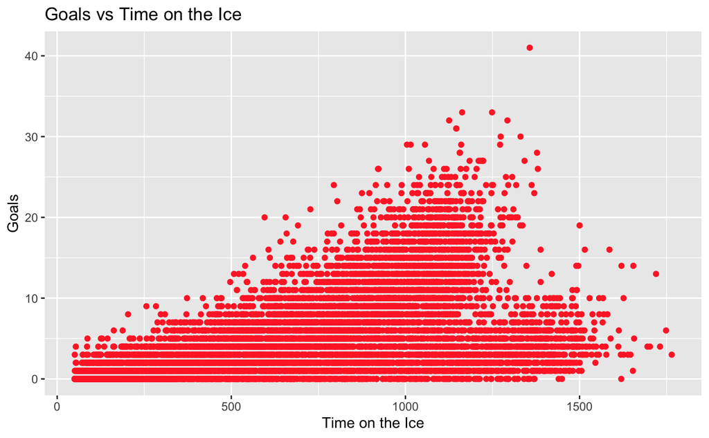

```r
ggplot(skaters,aes(x=toi,y=g))+geom_point(color="firebrick1")+ggtitle("Goals vs Time on the Ice")+labs(y="Goals",x="Time on the Ice")
```

As could be expected, the number of goals increases with the amount of ice team players enjoy. There does appear to be two player distributions which can be further investigated. Before investigating this grouping further, we model the data as described above.

```r
model1 <- lm(g~toi,data=skaters)
summary(model1)
```

```
Call:
lm(formula = g ~ toi, data = skaters)

Residuals:
    Min      1Q  Median      3Q     Max
-11.981  -2.764  -0.708   2.209  30.909

Coefficients:
             Estimate Std. Error t value Pr(>|t|)
(Intercept) 0.3368553  0.1002669    3.36 0.000784 ***
toi         0.0071891  0.0001236   58.15  < 2e-16 ***
---
Signif. codes:  0 ‘***’ 0.001 ‘**’ 0.01 ‘*’ 0.05 ‘.’ 0.1 ‘ ’ 1

Residual standard error: 4.692 on 9400 degrees of freedom
Multiple R-squared:  0.2645,    Adjusted R-squared:  0.2645
F-statistic:  3381 on 1 and 9400 DF,  p-value: < 2.2e-16
```

From the model summary it can be concluded that for the dataset as a whole, Time on the Ice does provides a powerful measure for predicting the number of goals based on a players time on the ice. The R-squared statistic is however low and the model requires further refinement.

Investigating this further, the plot is redrawn this times using player position as a color indicator.

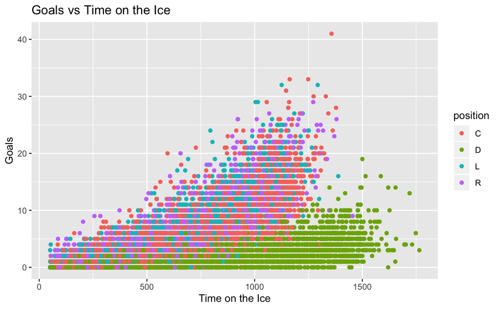

```r
ggplot(skaters,aes(x=toi,y=g))+geom_point(aes(color=position))+ggtitle("Goals vs Time on the Ice")+labs(y="Goals",x="Time on the Ice")
```

The distribution differences become clearer throught the visualisation, showing that defenders “D” tend to score less goals than forwards for similar amounts of time on the ice. Whilst expected, this is important to highlight for the purposes of the broader data modelling.

Next, similar plots are created for each of the different positions.

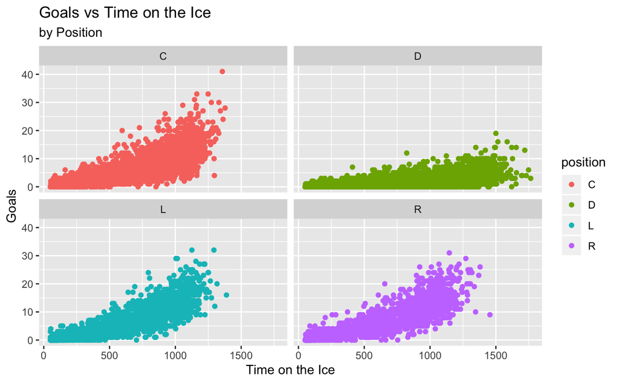

```r
ggplot(skaters,aes(x=toi,y=g))+geom_point(aes(color=position))+ggtitle("Goals vs Time on the Ice","by Position")+labs(y="Goals",x="Time on the Ice")+facet_wrap(vars(position))
```

The distribution of the defence players’ data is clearly different to that of the forwards and as such the data will be segmented along these lines.

```r
skaters = skaters %>%  mutate(positioncategory = if_else(position == "D", 'Defence', 'Forward'))
head(skaters)
```

| player | season | team | team2 | team3 | position | position2 | position3 | gp | toi | g | a | p | p1 | p_60 | p1_60 | gs | gs_60 | cf | ca | c_plumin | cf_pct | rel_cf_pct | gf | ga | g_plumin | gf_pct | rel_gf_pct | xgf | xga | … |
| --- | --- | --- | --- | --- | --- | --- | --- | --- | --- | --- | --- | --- | --- | --- | --- | --- | --- | --- | --- | --- | --- | --- | --- | --- | --- | --- | --- | --- | --- | --- |
| SEBASTIAN AHO | 2017-2018 | NYI | NA | NA | D | D | R | 22 | 324.64 | 0 | 3 | 3 | 1 | 0.55 | 0.18 | 1.99 | 0.37 | 289 | 325 | -36 | 47.07 | 2.26 | 15 | 19 | -4 | 44.12 | -0.48 | 10.49 | 15.73 | … |
| AARON DOWNEY | 2007-2008 | DET | NA | NA | R | NA | NA | 56 | 253.35 | 0 | 2 | 2 | 2 | 0.47 | 0.47 | 0.92 | 0.22 | 193 | 183 | 10 | 51.33 | -7.30 | 6 | 6 | 0 | 50.00 | -12.50 | 7.16 | 7.76 | … |
| AARON EKBLAD | 2014-2015 | FLA | NA | NA | D | NA | NA | 81 | 1400.56 | 6 | 16 | 22 | 14 | 0.94 | 0.60 | 38.10 | 1.63 | 1299 | 1112 | 187 | 53.88 | 3.83 | 59 | 43 | 16 | 57.84 | 11.78 | 50.88 | 42.32 | … |
| AARON EKBLAD | 2015-2016 | FLA | NA | NA | D | NA | NA | 78 | 1319.22 | 9 | 13 | 22 | 15 | 1.00 | 0.68 | 28.15 | 1.28 | 1059 | 1034 | 25 | 50.60 | 2.92 | 56 | 43 | 13 | 56.57 | -3.07 | 42.44 | 44.38 | … |
| AARON EKBLAD | 2016-2017 | FLA | NA | NA | D | NA | NA | 68 | 1132.67 | 4 | 7 | 11 | 7 | 0.58 | 0.37 | 21.36 | 1.13 | 1084 | 1003 | 81 | 51.94 | 1.97 | 30 | 47 | -17 | 38.96 | -7.58 | 38.23 | 42.23 | … |
| AARON EKBLAD | 2017-2018 | FLA | NA | NA | D | NA | NA | 82 | 1440.06 | 9 | 11 | 20 | 11 | 0.83 | 0.46 | 19.78 | 0.82 | 1392 | 1520 | -128 | 47.80 | -2.16 | 69 | 67 | 2 | 50.74 | 1.50 | 57.36 | 65.83 | … |

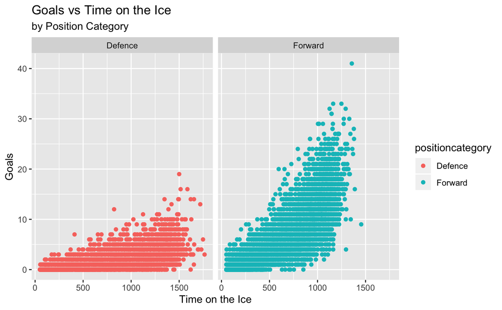

```r
ggplot(skaters,aes(x=toi,y=g))+geom_point(aes(color=positioncategory))+ggtitle("Goals vs Time on the Ice","by Position Category")+labs(y="Goals",x="Time on the Ice")+facet_wrap(vars(positioncategory))
```

```r
defence = subset(skaters,positioncategory == "Defence")
forwards = subset(skaters,positioncategory == "Forward")
head(defence)
```

| player | season | team | team2 | team3 | position | position2 | position3 | gp | toi | g | a | p | p1 | p_60 | p1_60 | gs | gs_60 | cf | ca | c_plumin | cf_pct | rel_cf_pct | gf | ga | g_plumin | gf_pct | rel_gf_pct | xgf | xga | … |
| --- | --- | --- | --- | --- | --- | --- | --- | --- | --- | --- | --- | --- | --- | --- | --- | --- | --- | --- | --- | --- | --- | --- | --- | --- | --- | --- | --- | --- | --- | --- |
| SEBASTIAN AHO | 2017-2018 | NYI | NA | NA | D | D | R | 22 | 324.64 | 0 | 3 | 3 | 1 | 0.55 | 0.18 | 1.99 | 0.37 | 289 | 325 | -36 | 47.07 | 2.26 | 15 | 19 | -4 | 44.12 | -0.48 | 10.49 | 15.73 | … |
| AARON EKBLAD | 2014-2015 | FLA | NA | NA | D | NA | NA | 81 | 1400.56 | 6 | 16 | 22 | 14 | 0.94 | 0.60 | 38.10 | 1.63 | 1299 | 1112 | 187 | 53.88 | 3.83 | 59 | 43 | 16 | 57.84 | 11.78 | 50.88 | 42.32 | … |
| AARON EKBLAD | 2015-2016 | FLA | NA | NA | D | NA | NA | 78 | 1319.22 | 9 | 13 | 22 | 15 | 1.00 | 0.68 | 28.15 | 1.28 | 1059 | 1034 | 25 | 50.60 | 2.92 | 56 | 43 | 13 | 56.57 | -3.07 | 42.44 | 44.38 | … |
| AARON EKBLAD | 2016-2017 | FLA | NA | NA | D | NA | NA | 68 | 1132.67 | 4 | 7 | 11 | 7 | 0.58 | 0.37 | 21.36 | 1.13 | 1084 | 1003 | 81 | 51.94 | 1.97 | 30 | 47 | -17 | 38.96 | -7.58 | 38.23 | 42.23 | … |
| AARON EKBLAD | 2017-2018 | FLA | NA | NA | D | NA | NA | 82 | 1440.06 | 9 | 11 | 20 | 11 | 0.83 | 0.46 | 19.78 | 0.82 | 1392 | 1520 | -128 | 47.80 | -2.16 | 69 | 67 | 2 | 50.74 | 1.50 | 57.36 | 65.83 | … |
| AARON EKBLAD | 2018-2019 | FLA | NA | NA | D | NA | NA | 82 | 1498.77 | 7 | 12 | 19 | 13 | 0.76 | 0.52 | 23.60 | 0.94 | 1402 | 1432 | -30 | 49.47 | 0.09 | 80 | 82 | -2 | 49.38 | 5.93 | 63.91 | 69.28 | … |

```r
head(forwards)
```

| player | season | team | team2 | team3 | position | position2 | position3 | gp | toi | g | a | p | p1 | p_60 | p1_60 | gs | gs_60 | cf | ca | c_plumin | cf_pct | rel_cf_pct | gf | ga | g_plumin | gf_pct | rel_gf_pct | xgf | xga | … |
| --- | --- | --- | --- | --- | --- | --- | --- | --- | --- | --- | --- | --- | --- | --- | --- | --- | --- | --- | --- | --- | --- | --- | --- | --- | --- | --- | --- | --- | --- | --- |
| AARON DOWNEY | 2007-2008 | DET | NA | NA | R | NA | NA | 56 | 253.35 | 0 | 2 | 2 | 2 | 0.47 | 0.47 | 0.92 | 0.22 | 193 | 183 | 10 | 51.33 | -7.30 | 6 | 6 | 0 | 50.00 | -12.50 | 7.16 | 7.76 | … |
| AARON GAGNON | 2010-2011 | DAL | NA | NA | C | NA | NA | 19 | 142.23 | 0 | 2 | 2 | 0 | 0.84 | 0.00 | 1.64 | 0.69 | 127 | 121 | 6 | 51.21 | 3.14 | 3 | 6 | -3 | 33.33 | -11.98 | 5.83 | 4.84 | … |
| AARON GAGNON | 2011-2012 | WPG | NA | NA | C | NA | NA | 7 | 65.34 | 0 | 0 | 0 | 0 | 0.00 | 0.00 | 1.17 | 1.07 | 72 | 58 | 14 | 55.38 | 8.63 | 0 | 1 | -1 | 0.00 | -45.45 | 2.89 | 2.15 | … |
| AARON GAGNON | 2012-2013 | WPG | NA | NA | C | NA | NA | 10 | 73.27 | 3 | 0 | 3 | 3 | 2.46 | 2.46 | 3.46 | 2.83 | 64 | 63 | 1 | 50.39 | 0.58 | 5 | 4 | 1 | 55.56 | 0.56 | 2.85 | 2.29 | … |
| AARON PALUSHAJ | 2011-2012 | MTL | NA | NA | R | NA | NA | 38 | 282.68 | 1 | 4 | 5 | 2 | 1.06 | 0.42 | 9.94 | 2.11 | 294 | 235 | 59 | 55.58 | 8.36 | 8 | 7 | 1 | 53.33 | 5.15 | 9.27 | 8.46 | … |
| AARON PALUSHAJ | 2012-2013 | COL | NA | NA | R | NA | NA | 25 | 261.62 | 1 | 7 | 8 | 4 | 1.83 | 0.92 | 8.37 | 1.92 | 248 | 244 | 4 | 50.41 | 2.70 | 12 | 14 | -2 | 46.15 | 5.31 | 10.24 | 9.55 | … |

Next models are fitted for the Defence and Forwards data sets respectively.

### Defence Model

```r
dmodel <- lm(g~poly(toi,3),data=defence)
summary(dmodel)
```

```
Call:
lm(formula = g ~ poly(toi, 3), data = defence)

Residuals:
    Min      1Q  Median      3Q     Max
-5.8556 -1.0410 -0.1856  0.7486 14.0545

Coefficients:
              Estimate Std. Error t value Pr(>|t|)
(Intercept)    2.17932    0.03094  70.433  < 2e-16 ***
poly(toi, 3)1 78.78889    1.77180  44.468  < 2e-16 ***
poly(toi, 3)2 12.71486    1.77180   7.176 8.82e-13 ***
poly(toi, 3)3  6.78823    1.77180   3.831  0.00013 ***
---
Signif. codes:  0 ‘***’ 0.001 ‘**’ 0.01 ‘*’ 0.05 ‘.’ 0.1 ‘ ’ 1

Residual standard error: 1.772 on 3275 degrees of freedom
Multiple R-squared:  0.3842,    Adjusted R-squared:  0.3837
F-statistic: 681.2 on 3 and 3275 DF,  p-value: < 2.2e-16
```

Using R-squared as a goodness of fit indicator, only 38% of the variation of the data is explained in the model so further model development may be required.

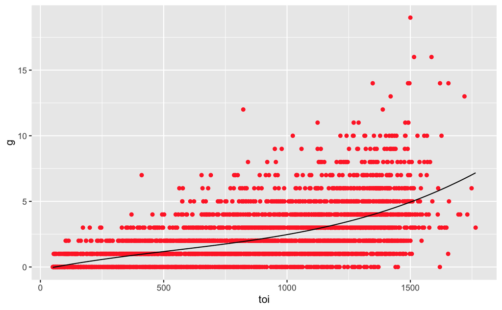

```r
dgrid = data_grid(defence,toi)
dgrid = add_predictions(dgrid,dmodel,var="pred")
ggplot(defence,aes(x=toi,y=g))+geom_point(color="firebrick1")+geom_line(data=dgrid,aes(y=pred,x=toi))
```

### Forwards Model

```r
fmodel <- lm(g ~ poly(toi,3), data=forwards)
summary(fmodel)
```

```
Call:
lm(formula = g ~ poly(toi, 3), data = forwards)

Residuals:
     Min       1Q   Median       3Q      Max
-15.8948  -1.8615  -0.2938   1.5328  19.5426

Coefficients:
               Estimate Std. Error t value Pr(>|t|)
(Intercept)     7.19108    0.04279 168.068  < 2e-16 ***
poly(toi, 3)1 370.90836    3.34804 110.784  < 2e-16 ***
poly(toi, 3)2  68.46260    3.34804  20.449  < 2e-16 ***
poly(toi, 3)3  14.70591    3.34804   4.392 1.14e-05 ***
---
Signif. codes:  0 ‘***’ 0.001 ‘**’ 0.01 ‘*’ 0.05 ‘.’ 0.1 ‘ ’ 1

Residual standard error: 3.348 on 6119 degrees of freedom
Multiple R-squared:  0.675, Adjusted R-squared:  0.6749
F-statistic:  4237 on 3 and 6119 DF,  p-value: < 2.2e-16
```

Using R-squared as a goodness of fit indicator, only 67% of the variation of the data is explained in the model.

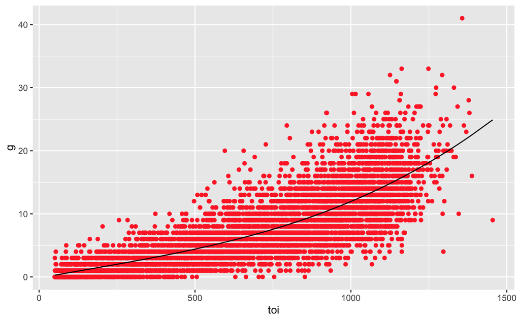

```r
fgrid = data_grid(forwards,toi)
fgrid = add_predictions(fgrid,fmodel,var="pred")
ggplot(forwards,aes(x=toi,y=g))+geom_point(color="firebrick1")+geom_line(data=fgrid,aes(y=pred,x=toi))
```

### Conclusion

Based on the evidence presented, the following conclusions can be drawn:

- It has been show that increased time on the ice leads to increased goal production
- Position is a clear indicator for the number of expected goals